# Project 1 Presentation

2022-10-13

## Introduction

## Airline Customer Satisfaction

- Data: customer satisfaction survey from some airline
- Source of Data: https://www.kaggle.com/datasets/teejmahal20/airline-passenger-satisfaction?select=train.csv

## The data

The original columns of the data set from Kaggle:

- X: index starting at 0
- “Gender: Gender of the passengers (Female, Male)
- Customer Type: The customer type (Loyal customer, disloyal customer)
- Age: The actual age of the passengers
- Type of Travel: Purpose of the flight of the passengers (Personal Travel, Business Travel)
- Class: Travel class in the plane of the passengers (Business, Eco, Eco Plus)
- Flight distance: The flight distance of this journey
- Departure Delay in Minutes: Minutes delayed when departure
- Arrival Delay in Minutes: Minutes delayed when Arrival

## The data (the amenities)

(Satisfaction level = 0 for Not Applicable and scale 1-5; 1 having the least and 5 having the most)

- Inflight wifi service: Satisfaction level of the inflight wifi service
- Departure/Arrival time convenient: Satisfaction level of Departure/Arrival time convenient
- Ease of Online booking: Satisfaction level of online booking
- Gate location: Satisfaction level of Gate location
- Food and drink: Satisfaction level of Food and drink
- Online boarding: Satisfaction level of online boarding

## The data (the amenities)

- Seat comfort: Satisfaction level of Seat comfort
- Inflight entertainment: Satisfaction level of inflight entertainment
- On-board service: Satisfaction level of On-board service
- Leg room service: Satisfaction level of Leg room service
- Baggage handling: Satisfaction level of baggage handling
- Check-in service: Satisfaction level of Check-in service
- Inflight service: Satisfaction level of inflight service
- Cleanliness: Satisfaction level of Cleanliness

## The Data (continued)

- Satisfaction: Airline satisfaction level(Satisfaction, neutral or dissatisfaction)”
- Departure Delay in Minutes: Minutes delayed when departure
- Arrival Delay in Minutes: Minutes delayed when Arrival

## Problems

## Problems to solve for this project

- Determine whether the participants are overall satisfied or not? Who? Why?
- Can I predict satisfaction according to the customer classifications?
- Which amenities should the airline improve on?

## Clean up and Data wrangling

## Check the data

-look for NA’s or other unwanted characters

```r
summary(survey)
```

```
##        X                id            Gender          Customer.Type
##  Min.   :     0   Min.   :     1   Length:103904      Length:103904
##  1st Qu.: 25976   1st Qu.: 32534   Class :character   Class :character
##  Median : 51952   Median : 64857   Mode  :character   Mode  :character
##  Mean   : 51952   Mean   : 64924
##  3rd Qu.: 77927   3rd Qu.: 97368
##  Max.   :103903   Max.   :129880
##
##       Age        Type.of.Travel        Class           Flight.Distance
##  Min.   : 7.00   Length:103904      Length:103904      Min.   :  31
##  1st Qu.:27.00   Class :character   Class :character   1st Qu.: 414
##  Median :40.00   Mode  :character   Mode  :character   Median : 843
##  Mean   :39.38                                         Mean   :1189
##  3rd Qu.:51.00                                         3rd Qu.:1743
##  Max.   :85.00                                         Max.   :4983
##
##  Inflight.wifi.service Departure.Arrival.time.convenient Ease.of.Online.booking
##  Min.   :0.00          Min.   :0.00                      Min.   :0.000
##  1st Qu.:2.00          1st Qu.:2.00                      1st Qu.:2.000
##  Median :3.00          Median :3.00                      Median :3.000
##  Mean   :2.73          Mean   :3.06                      Mean   :2.757
##  3rd Qu.:4.00          3rd Qu.:4.00                      3rd Qu.:4.000
##  Max.   :5.00          Max.   :5.00                      Max.   :5.000
##
##  Gate.location   Food.and.drink  Online.boarding  Seat.comfort
##  Min.   :0.000   Min.   :0.000   Min.   :0.00    Min.   :0.000
##  1st Qu.:2.000   1st Qu.:2.000   1st Qu.:2.00    1st Qu.:2.000
##  Median :3.000   Median :3.000   Median :3.00    Median :4.000
##  Mean   :2.977   Mean   :3.202   Mean   :3.25    Mean   :3.439
##  3rd Qu.:4.000   3rd Qu.:4.000   3rd Qu.:4.00    3rd Qu.:5.000
##  Max.   :5.000   Max.   :5.000   Max.   :5.00    Max.   :5.000
##
##  Inflight.entertainment On.board.service Leg.room.service Baggage.handling
##  Min.   :0.000          Min.   :0.000    Min.   :0.000    Min.   :1.000
##  1st Qu.:2.000          1st Qu.:2.000    1st Qu.:2.000    1st Qu.:3.000
##  Median :4.000          Median :4.000    Median :4.000    Median :4.000
##  Mean   :3.358          Mean   :3.382    Mean   :3.351    Mean   :3.632
##  3rd Qu.:4.000          3rd Qu.:4.000    3rd Qu.:4.000    3rd Qu.:5.000
##  Max.   :5.000          Max.   :5.000    Max.   :5.000    Max.   :5.000
##
##  Checkin.service Inflight.service  Cleanliness    Departure.Delay.in.Minutes
##  Min.   :0.000   Min.   :0.00     Min.   :0.000   Min.   :   0.00
##  1st Qu.:3.000   1st Qu.:3.00     1st Qu.:2.000   1st Qu.:   0.00
##  Median :3.000   Median :4.00     Median :3.000   Median :   0.00
##  Mean   :3.304   Mean   :3.64     Mean   :3.286   Mean   :  14.82
##  3rd Qu.:4.000   3rd Qu.:5.00     3rd Qu.:4.000   3rd Qu.:  12.00
##  Max.   :5.000   Max.   :5.00     Max.   :5.000   Max.   :1592.00
##
##  Arrival.Delay.in.Minutes satisfaction
##  Min.   :   0.00          Length:103904
##  1st Qu.:   0.00          Class :character
##  Median :   0.00          Mode  :character
##  Mean   :  15.18
##  3rd Qu.:  13.00
##  Max.   :1584.00
##  NA's   :310
```

## Factoring

```r
cleanSurvey = data.frame(Class = factor(survey$Class)) #creating cleanSurvey
cleanSurvey$Customer.Type = factor(survey$Customer.Type)
cleanSurvey$Type.of.Travel = factor(survey$Type.of.Travel)
cleanSurvey$Gender = factor(survey$Gender)
cleanSurvey$satisfaction = factor(survey$satisfaction, labels = c("not satisfied", "satisfied"))
cleanSurvey$Age = survey$Age #add age to cleanSurvey
```

## Add new columns: Age group

-NEW: Age.Group: organize Age

```r
Age.Group <- survey %>% select(Age) %>% mutate(Age.Group = case_when(
      Age <= 14            ~ "<=14",
      Age > 14 & Age <= 29 ~ "15-29",
      Age > 29 & Age <= 49 ~ "30-49",
      Age > 49 & Age <= 64 ~ "50-64",
      Age > 64             ~ "65+"))
cleanSurvey$Age.Group <- as.factor(Age.Group$Age.Group) #factoring Age.Group
cleanSurvey <- cbind(cleanSurvey, survey[9:22])  #add the amenities to CleanSurvey
```

## Add more columns: Satisfaction Score

-New: measure satisfaction: satisfyScore -scale (1-70) of how satisfied the customer is

```r
score = rowSums(cleanSurvey[8:21])
cleanSurvey <- mutate(cleanSurvey, satisfyScore = score)
```

## Verify Data

```
## 'data.frame':    103904 obs. of  22 variables:
##  $ Class                            : Factor w/ 3 levels "Business","Eco",..: 3 1 1 1 1 2 2 1 1 2 ...
##  $ Customer.Type                    : Factor w/ 2 levels "disloyal Customer",..: 2 1 2 2 2 2 2 2 2 1 ...
##  $ Type.of.Travel                   : Factor w/ 2 levels "Business travel",..: 2 1 1 1 1 2 2 1 1 1 ...
##  $ Gender                           : Factor w/ 2 levels "Female","Male": 2 2 1 1 2 1 2 1 1 2 ...
##  $ satisfaction                     : Factor w/ 2 levels "not satisfied",..: 1 1 2 1 2 1 1 2 1 1 ...
##  $ Age                              : int  13 25 26 25 61 26 47 52 41 20 ...
##  $ Age.Group                        : Factor w/ 5 levels "<=14","15-29",..: 1 2 2 2 4 2 3 4 3 2 ...
##  $ Inflight.wifi.service            : int  3 3 2 2 3 3 2 4 1 3 ...
##  $ Departure.Arrival.time.convenient: int  4 2 2 5 3 4 4 3 2 3 ...
##  $ Ease.of.Online.booking           : int  3 3 2 5 3 2 2 4 2 3 ...
##  $ Gate.location                    : int  1 3 2 5 3 1 3 4 2 4 ...
##  $ Food.and.drink                   : int  5 1 5 2 4 1 2 5 4 2 ...
##  $ Online.boarding                  : int  3 3 5 2 5 2 2 5 3 3 ...
##  $ Seat.comfort                     : int  5 1 5 2 5 1 2 5 3 3 ...
##  $ Inflight.entertainment           : int  5 1 5 2 3 1 2 5 1 2 ...
##  $ On.board.service                 : int  4 1 4 2 3 3 3 5 1 2 ...
##  $ Leg.room.service                 : int  3 5 3 5 4 4 3 5 2 3 ...
##  $ Baggage.handling                 : int  4 3 4 3 4 4 4 5 1 4 ...
##  $ Checkin.service                  : int  4 1 4 1 3 4 3 4 4 4 ...
##  $ Inflight.service                 : int  5 4 4 4 3 4 5 5 1 3 ...
##  $ Cleanliness                      : int  5 1 5 2 3 1 2 4 2 2 ...
##  $ satisfyScore                     : num  54 32 52 42 49 35 39 63 29 41 ...
```

## Data Analysis

## Gender

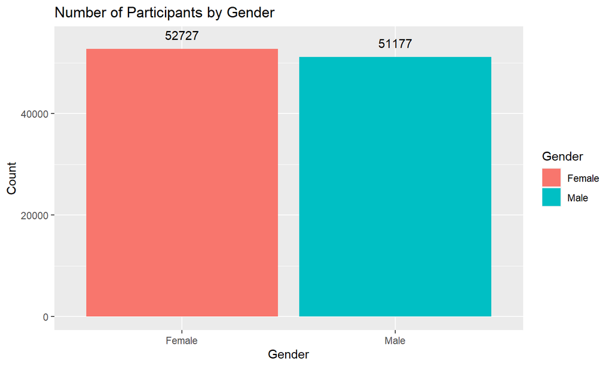

## Customer Type/Loyalty

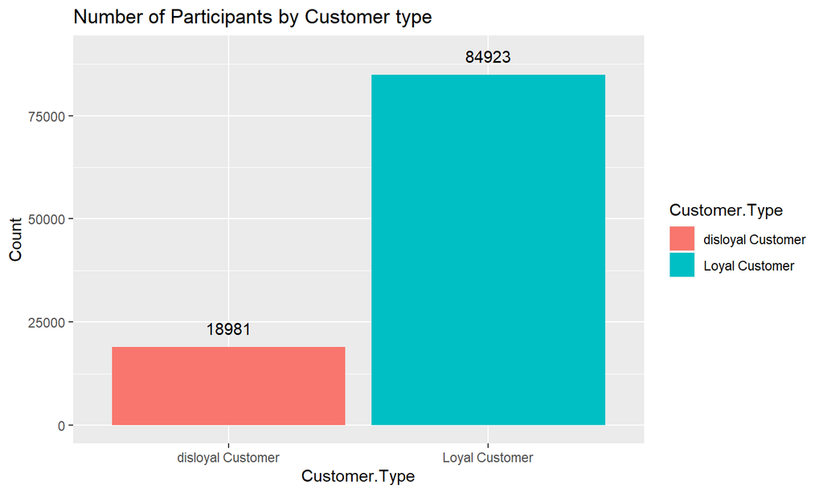

## Class

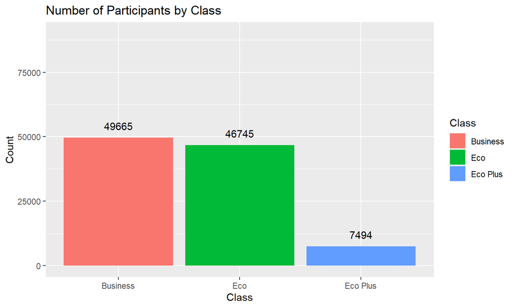

## Age

```
##
## Summary of Age
```

```
##    Min. 1st Qu.  Median    Mean 3rd Qu.    Max.
##    7.00   27.00   40.00   39.38   51.00   85.00
```

## Age Group

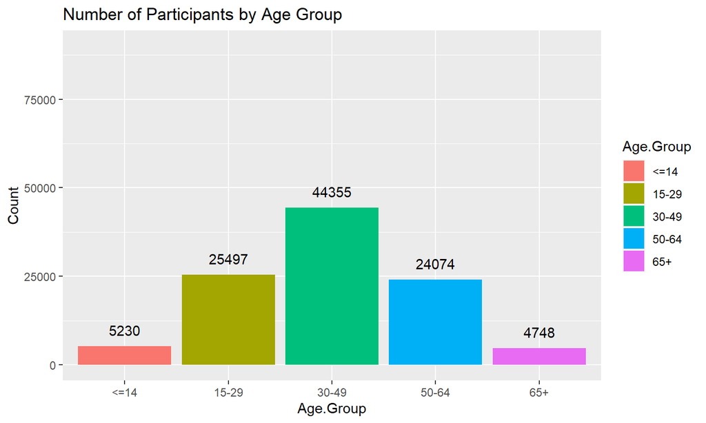

## Are they overall satisfied?

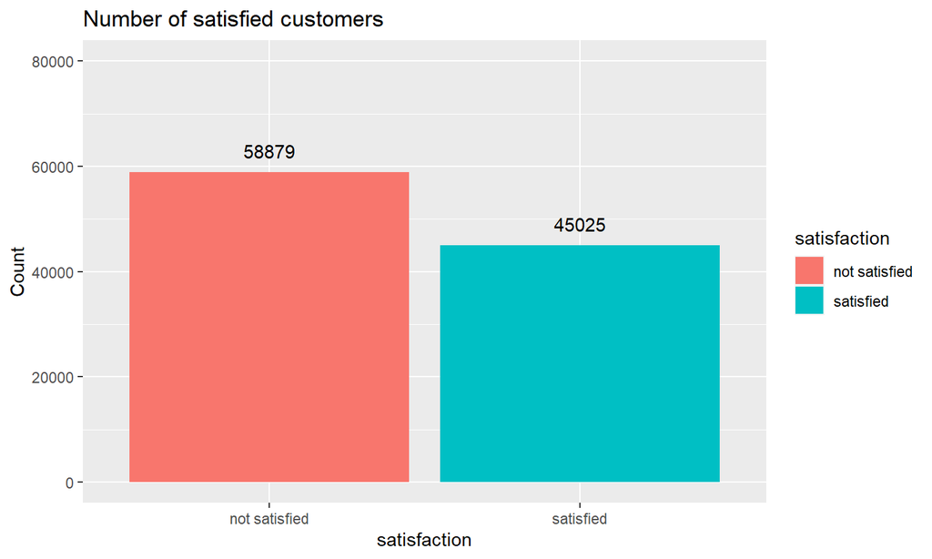

## Amenities by Class

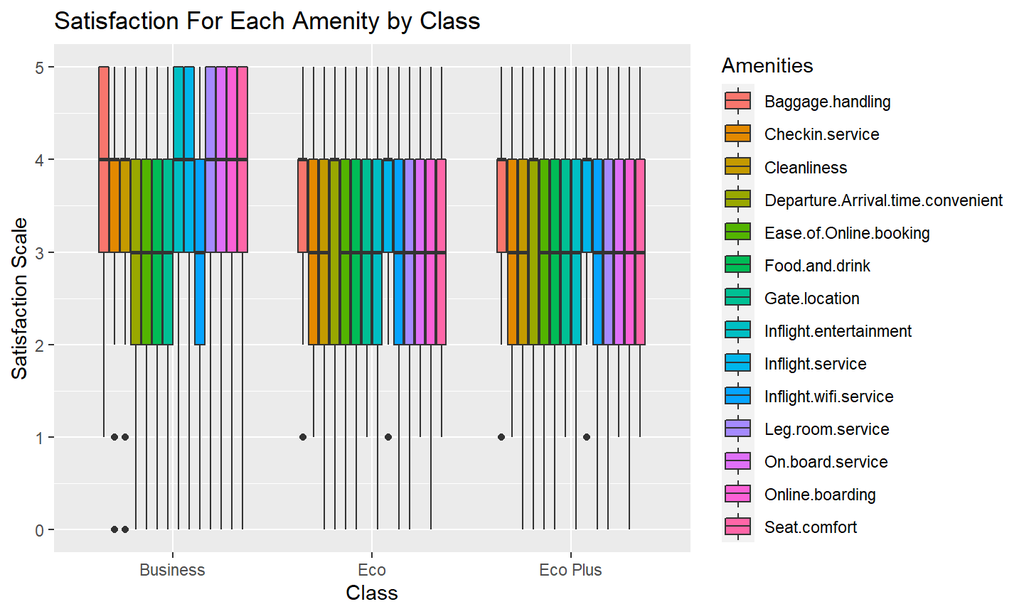

## Amenities by Gender

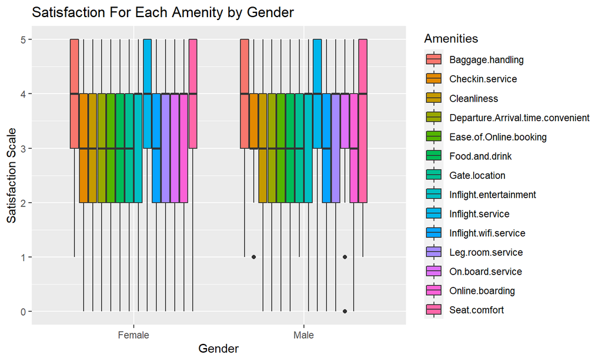

## Amenities by Customer Type

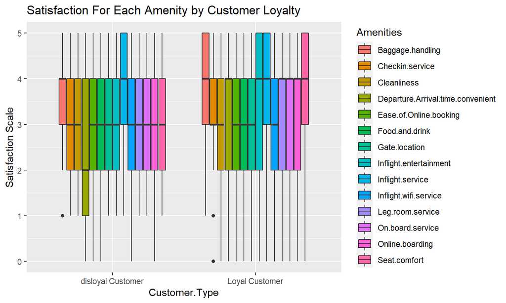

## Amenities by Age Group

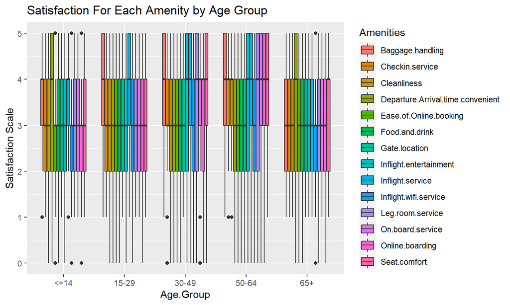

## Simple Regression

```
##
## Call:
## lm(formula = satisfyScore ~ Gender + Customer.Type + Class +
##     Age, data = cleanSurvey)
##
## Residuals:
##    Min     1Q Median     3Q    Max
## -33.01  -5.98   0.41   6.42  27.32
##
## Coefficients:
##                             Estimate Std. Error t value Pr(>|t|)
## (Intercept)                 45.06493    0.09890  455.65   <2e-16 ***
## GenderMale                   0.12876    0.05492    2.34    0.019 *
## Customer.TypeLoyal Customer  2.57218    0.07441   34.57   <2e-16 ***
## ClassEco                    -4.78903    0.05771  -82.98   <2e-16 ***
## ClassEco Plus               -5.14393    0.10989  -46.81   <2e-16 ***
## Age                          0.01689    0.00191    8.86   <2e-16 ***
## ---
## Signif. codes:  0 '***' 0.001 '**' 0.01 '*' 0.05 '.' 0.1 ' ' 1
##
## Residual standard error: 8.84 on 103898 degrees of freedom
## Multiple R-squared:  0.0888, Adjusted R-squared:  0.0887
## F-statistic: 2.02e+03 on 5 and 103898 DF,  p-value: <2e-16
```

## Prediction

```
## Summary for Percent Error of Prediction
```

```
##    Min. 1st Qu.  Median    Mean 3rd Qu.    Max.
##   0.369   7.104  15.788  17.896  24.840 185.610
```

```
##
## Prediction is 84.212% accurate
```

## Conclusion

## Conclusion

Least Satisfied: Eco and Eco plus and disloyal customers

Satisfied: Business and loyal customers

Major Factors of Satisfaction: Class and customer type/loyalty

Improvements: inflight wifi service, ease of Online booking, cleanliness, and departure/arrival time convenient